# World Development Indicators (2022) Report

AC

2025-10-06

## Intro

- The World Development Indicators (WDI) dataset, compiled by the World Bank, provides a comprehensive collection of internationally comparable statistics about global development (World Bank, 2022).
- Highlight three core indicators:
  - Education expenditure (% of GDP)
  - Health expenditure (% of GDP)
  - Life expectancy (in years)
- Analyzes resource allocation and human capital development.

## Key Findings on Education Expenditure

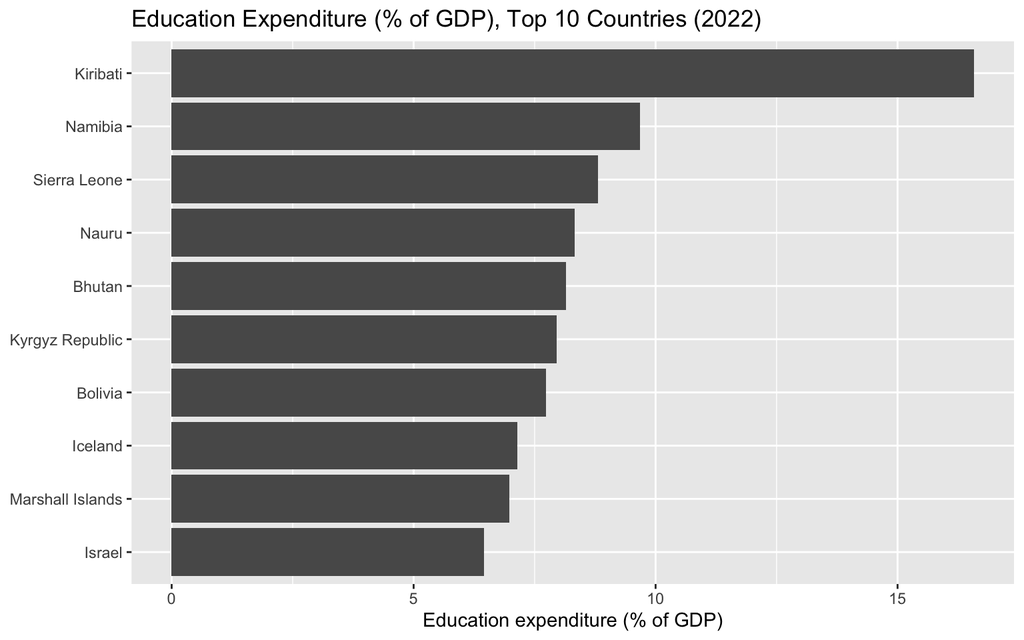

Figure 1: Top 10 countries by education expenditure as a share of GDP (2022). Source: World Development Indicators (wdi.csv).

Kiribati leads, suggesting small nations prioritize education.

## Health Expenditure vs. Life Expectancy

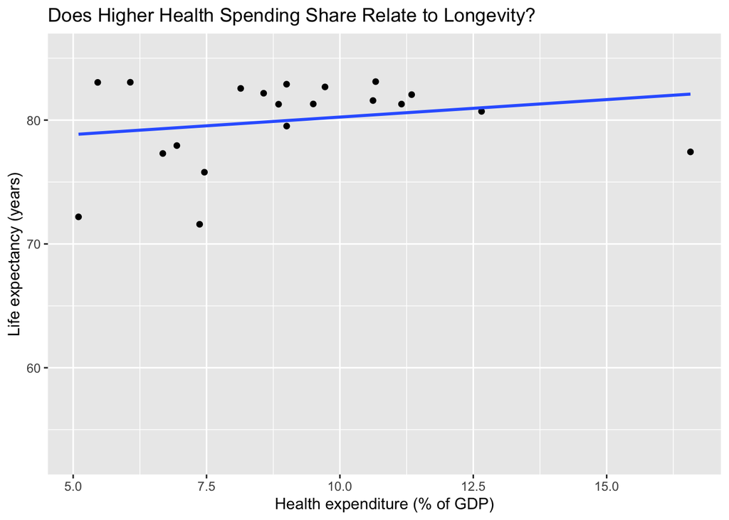

Figure 2: Health expenditure (% of GDP) vs. life expectancy (years), 2022. Line shows linear fit. Source: World Development Indicators (wdi.csv).

Weak positive association, limited by 197 missing values.

## Summary Table

Table 1: Key statistics for 2022 indicators. Source: World Development Indicators (wdi.csv).

| Indicator | Mean | Median | Min | Max | Missing |
| --- | --- | --- | --- | --- | --- |
| Education Expenditure (% GDP) | 4.23 | 3.89 | 1.03 | 16.58 | 112 |
| Health Expenditure (% GDP) | 9.04 | 8.93 | 5.10 | 16.57 | 197 |
| Life Expectancy (Years) | 72.42 | 73.51 | 53.00 | 85.38 | 8 |

Wide ranges and missing data suggest reporting gaps.

## Insights

- Top ten education spenders are predominantly small or developing nations, indicating that percentage-of-GDP metrics can overstate investment intensity.
- The weak but positive relationship between health expenditure and life expectancy supports the view that financial inputs are necessary but insufficient; system design and efficiency are crucial.
- The high level of missing data highlights an urgent need for improved international reporting standards.
- Modest correlation between education expenditure and life expectancy reflects broader structural factors.

## Future Implications

Policymakers could focus on:

- enhancing efficiency and quality of investments
- prioritizing early childhood education and preventive healthcare
- improving data transparency.

## References

- Center for Sustainable Systems, University of Michigan. (2025). *Social development indicators factsheet*. https://css.umich.edu/publications/factsheets/sustainability-indicators/social-development-indicators-factsheet
- Harry A. Patrinos. (2023). *Investing in tomorrow*. https://blogs.worldbank.org/en/education/investing-tomorrow-how-educational-spending-translates-lifelong-returns
- Learning Policy Institute. (2024). *How money matters*. https://learningpolicyinstitute.org/product/how-money-matters-factsheet
- World Bank. (2022). *World development indicators*. https://databank.worldbank.org/source/world-development-indicators